# Import Libraries and Data

```python
# import os
# os.environ["CUDA_DEVICE_ORDER"] = "PCI_BUS_ID"
# os.environ["CUDA_VISIBLE_DEVICES"] = "-1"

import tensorflow as tf
tf.config.list_physical_devices('GPU')
```

```
[PhysicalDevice(name='/physical_device:GPU:0', device_type='GPU')]
```

```python
import numpy as np
import pandas as pd
```

```python
from keras.datasets import fashion_mnist

(X_train, y_train), (X_test, y_test) = fashion_mnist.load_data()

print(f"X_train.shape = {X_train.shape}, y_train.shape = {y_train.shape}")
print(f"X_test.shape = {X_test.shape}, y_test.shape = {y_test.shape}")
print()
```

```
X_train.shape = (60000, 28, 28), y_train.shape = (60000,)
X_test.shape = (10000, 28, 28), y_test.shape = (10000,)
```

# EDA

## Background

The Fashion-MNIST dataset is an improved version of a classic neural entwork training set, the MNIST hadnwritten digits set. \ According to the Keras docs,

> This is a dataset of 60,000 28x28 grayscale images of 10 fashion categories, along with a test set of 10,000 images. This dataset can be used as a drop-in replacement for MNIST.

> The original MNIST dataset was a similar set of 60,000 28x28 grayscale images as well, also with 10, 000 test images. The ony differnece was that it contained hadnwritten digits instead of clothing items.

The reason the Fashion-MNIST set was created as a "drop-in replacement" for MNIST was because it was too easy to score well on, consisting of images made up of simple lines and curves. With a more complex setting like clothings with different sizes and patterns, the Fashion-MNIST is more analagous to the more modern applications of Computer Vision and can help set a more realistic benchmark for practical purposes

## Functions and Libraries

```python
import matplotlib.pyplot as plt
import seaborn as sns

import plotly.express as px
from plotly.subplots import make_subplots
import plotly.graph_objects as go
```

```python
# Creates appropriately sized plt subplot for a number of desire axes
from math import ceil


def create_subplots_axs(n_plots, n_cols=3, plot_h=2, plot_w=2):
    n_rows = ceil(n_plots / n_cols)

    fig, axs = plt.subplots(
        nrows=n_rows, ncols=n_cols, figsize=(plot_w * n_cols, plot_h * n_rows), constrained_layout=True
    )

    ## add .flatten() method to flat subplots
    if not isinstance(axs, list):
        axs = np.array(axs)

    ## turn off plots on the grid that aren't being used
    for ax in axs.flatten()[n_plots:]:
        ax.set_axis_off()

    return fig, axs
```

```python
def plot_class_agg(images, label_indexes, agg_func, **visual_kwargs):
    fig, axs = plt.subplots(1, 10, constrained_layout=True, figsize=(10 * 2, 1 * 2))
    class_labels = label_indexes.columns

    for ax, label in zip(axs, class_labels):
        agg_images = agg_func(images[label_indexes[label]], axis=0)

        ax.imshow(agg_images, **visual_kwargs)
        ax.set_title(label)

    return fig, axs
```

```python
labels = [
    "T-shirt/top",
    "Trousers",
    "Pullover",
    "Dress",
    "Coat",
    "Sandal",
    "Shirt",
    "Sneaker",
    "Bag",
    "Ankle boot",
]
```

## Text Summary

```python
_, train_counts = np.unique(y_train, return_counts=True)
unique_labels_num, test_counts = np.unique(y_test, return_counts=True)
unique_labels_num = pd.Series(unique_labels_num, name="Classes")

counts = np.vstack((train_counts, test_counts)).T

class_dist = pd.DataFrame(counts, index=unique_labels_num, columns=["Train Dist.", "Test Dist."])
display(class_dist)

# All classes are balanced
```

| Classes | Train Dist. | Test Dist. |
| --- | --- | --- |
| 0 | 6000 | 1000 |
| 1 | 6000 | 1000 |
| 2 | 6000 | 1000 |
| 3 | 6000 | 1000 |
| 4 | 6000 | 1000 |
| 5 | 6000 | 1000 |
| 6 | 6000 | 1000 |
| 7 | 6000 | 1000 |
| 8 | 6000 | 1000 |
| 9 | 6000 | 1000 |

```python
print(f"Train minimum: {np.min(X_train)}, Train maximum: {np.max(X_train)}")
print(f"Test minimum: {np.min(X_test)}, Test maximum: {np.max(X_test)}")

# Might need to rescale pixel values
```

```
Train minimum: 0, Train maximum: 255
Test minimum: 0, Test maximum: 255
```

## Categorise Data

```python
labels = [
    "T-shirt/top",
    "Trousers",
    "Pullover",
    "Dress",
    "Coat",
    "Sandal",
    "Shirt",
    "Sneaker",
    "Bag",
    "Ankle boot",
]

train_indexes = pd.DataFrame()
test_indexes = pd.DataFrame()
for label_num in unique_labels_num:
    train_indexes[labels[label_num]] = np.where(y_train == label_num)[0]
    test_indexes[labels[label_num]] = np.where(y_test == label_num)[0]


display(train_indexes)
display(test_indexes)
```

## Visualisation

```python
visual_kwargs = {
    "cmap": plt.cm.gray,
    "vmin": 0,
    "vmax": 255
}
```

[figure not shown]

[figure not shown]

```
'\nstandard images, samples seem to be correctly labeled \nsome sneakers are flipped compared to the other samples\n'
```

```python
n_samples = 3

### Train
fig, axs = create_subplots_axs(n_plots=10 * n_samples, n_cols=10)
# plot sample images for each of the 10 classes vertically
for axs_column, label in zip(axs.T, labels):

    for ax, label_index in zip(axs_column, train_indexes[label]):
        ax.imshow(X_train[label_index], **visual_kwargs)

# add class label to first plot in each col
for ax, label in zip(axs[0], labels):
    ax.set_title(label)


### Test
fig, axs = create_subplots_axs(n_plots=10 * n_samples, n_cols=10)
# plot sample images for each of the 10 classes vertically
for axs_column, label in zip(axs.T, labels):

    for ax, label_index in zip(axs_column, test_indexes[label]):
        ax.imshow(X_test[label_index], **visual_kwargs)

# add class label to first plot in each col
for ax, label in zip(axs[0], labels):
    ax.set_title(label)

plt.show()


"""
standard images, samples seem to be correctly labeled
some sneakers are flipped compared to the other samples
"""
```

Now that we haved looked at a few samples, let's try to understand the entire dataset at once using aggregate metrics to see if any interesting patterns show up

### Average Pixel Values

```
Average pixel values:
```

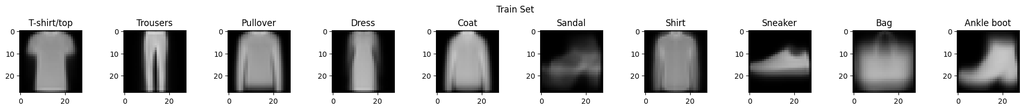

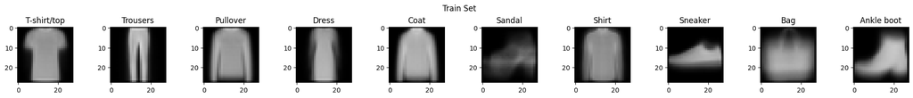

```python
print("Average pixel values:")

fig, axs = plot_class_agg(X_train, train_indexes, agg_func=np.mean, **visual_kwargs)
fig.suptitle("Train Set")
plt.show()

fig, axs = plot_class_agg(X_test, test_indexes, agg_func=np.mean, **visual_kwargs)
fig.suptitle("Train Set")
plt.show()

"""
averages correspond very well to their labels, immediaately recognizable
although shirt, coat and pullover have similar averages, there are still distinctions like
a thinner collar on coats, wider chests on shirts
"""
```

### Maximum Pixel Values

```
Maximum pixel values:
```

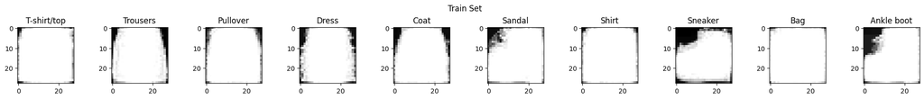

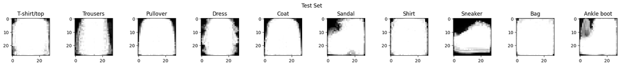

```python
print("Maximum pixel values:")

fig, axs = plot_class_agg(X_train, train_indexes, agg_func=np.max, **visual_kwargs)
fig.suptitle("Train Set")
plt.show()

fig, axs = plot_class_agg(X_test, test_indexes, agg_func=np.max, **visual_kwargs)
fig.suptitle("Test Set")
plt.show()

"""
maximums are still vaguely recognizable as they're classes
all classes have a black border around them, so the border pixels contain little to no information
there seems to be an ankle boot example that is flipped the opposite direction compare to all the others in the test class
"""
```

### Minimum Pixel Values

```
Minimum pixel values:
```

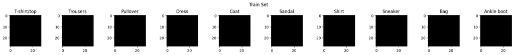

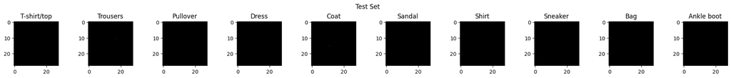

```python
print("Minimum pixel values:")

fig, axs = plot_class_agg(X_train, train_indexes, agg_func=np.min, **visual_kwargs)
fig.suptitle("Train Set")
plt.show()

fig, axs = plot_class_agg(X_test, test_indexes, agg_func=np.min, **visual_kwargs)
fig.suptitle("Test Set")
plt.show()

"""
All minimums are completely dark, meaning that there are no sections that are consitently activated for any of the classes,
maybe things like stripes or colors result in little overlap of bright pixels in the classes
(or maybe there are some black images included in the data, which is a scary though)
"""
```

```python
## check for same colour images

import random
for i, image in enumerate(X_train):
    random_pixel = image[random.randint(0,27)][random.randint(0,27)]
    if np.all(image.flatten() == random_pixel):
        print(f"Train empty: {i}")

    ## repeat for confidence
    random_pixel = image[random.randint(0,27)][random.randint(0,27)]
    if np.all(image.flatten() == random_pixel):
        print(f"Train empty: {i}")

for i, image in enumerate(X_test):
    random_pixel = image[random.randint(0,27)][random.randint(0,27)]

    if np.all(image.flatten() == random_pixel):
        print("Test empty: {i}")

    random_pixel = image[random.randint(0,27)][random.randint(0,27)]
    if np.all(image.flatten() == random_pixel):
        print(f"Train empty: {i}")

"""
no matches, thank god
"""
```

```
'\nno matches, thank god\n'
```

# Modelling

## Libraries and Functions

```python
tf.random.set_seed(39)
```

```python
import keras

from tensorflow.keras import Input
from tensorflow.keras.models import Sequential, clone_model, Model
from tensorflow.keras.layers import (
    Dense,
    Conv2D,
    MaxPooling2D,
    Flatten,
    ZeroPadding2D,
    Rescaling,
    BatchNormalization,
    Dropout,
    SpatialDropout2D
)
from tensorflow.keras.callbacks import EarlyStopping, CSVLogger, ModelCheckpoint
from tensorflow.keras.losses import CategoricalCrossentropy
from tensorflow.keras.utils import to_categorical
```

```python
pixel_scaler = Rescaling(1.0 / 255)
fashion_input = Input(shape=(28, 28, 1))
```

```python
earlyStop = EarlyStopping(monitor="val_loss", patience=15, restore_best_weights=True)
```

```python
def plot_learning_curves(history, metrics=["accuracy", "loss"], yranges=[[0.5, 1], [0, 2.302]]):
    if isinstance(history, keras.callbacks.History):
        epochs = list(range(1, history.params["epochs"] + 1))
        history = history.history
    elif isinstance(history, pd.DataFrame):
        epochs = list(range(1, len(history) + 1))

    fig = make_subplots(
        rows=ceil(len(metrics) / 3),
        cols=min(3, len(metrics)),
        subplot_titles=[f"Model {metric}" for metric in metrics],
    )

    showlegend = True
    for i, metric in enumerate(metrics):
        row = (i + 3) // 3
        col = (i % 3) + 1

        fig.add_trace(
            go.Scatter(
                x=epochs,
                y=history[metric],
                name="train",
                showlegend=showlegend,
                line={"color": "blue"},
            ),
            row=row,
            col=col,
        )
        fig.add_trace(
            go.Scatter(
                x=epochs,
                y=history[f"val_{metric}"],
                name="val",
                showlegend=showlegend,
                line={"color": "orange"},
            ),
            row=row,
            col=col,
        )

        if yranges[i]:
            fig.update_yaxes(range=yranges[i], row=row, col=col)

        showlegend = False

    fig.show()
```

```python
def plot_activation_map(img, preprocessing, input, outputs):
    img = preprocessing(img)
    model = Model(inputs=input, outputs=outputs)

    feature_maps = model.predict(img)
```

```python
from sklearn.model_selection import train_test_split
from sklearn.metrics import confusion_matrix, ConfusionMatrixDisplay
```

```python
def plot_confusion_matrix(model, X_test, y_test, labels, ax=None):
    y_pred = np.argmax(model.predict(X_test), axis=1)

    disp = ConfusionMatrixDisplay.from_predictions(
        y_test,
        y_pred,
        display_labels=labels,
        cmap=plt.cm.Blues,
        xticks_rotation="vertical",
        normalize=None,
        ax=ax
    )
```

## Validation Split

```python
X_train, X_val, y_train, y_val = train_test_split(
    X_train, y_train, test_size=5000, stratify=y_train
)

print(f"X_train.shape = {X_train.shape}, y_train.shape = {y_train.shape}")
print(f"X_val.shape = {X_val.shape}, y_val.shape = {y_val.shape}")
print(f"X_test.shape = {X_test.shape}, y_test.shape = {y_test.shape}")
print()
```

```
X_train.shape = (55000, 28, 28), y_train.shape = (55000,)
X_val.shape = (5000, 28, 28), y_val.shape = (5000,)
X_test.shape = (10000, 28, 28), y_test.shape = (10000,)
```

```python
_, train_counts = np.unique(y_train, return_counts=True)
_, val_counts = np.unique(y_val, return_counts=True)
unique_labels_num, test_counts = np.unique(y_test, return_counts=True)
unique_labels_num = pd.Series(unique_labels_num, name="Classes")

counts = np.vstack((train_counts, test_counts, val_counts)).T

class_dist = pd.DataFrame(counts, index=unique_labels_num, columns=["Train Dist.", "Test Dist.", "Val Dist."])
display(class_dist)
```

| Classes | Train Dist. | Test Dist. | Val Dist. |
| --- | --- | --- | --- |
| 0 | 5500 | 1000 | 500 |
| 1 | 5500 | 1000 | 500 |
| 2 | 5500 | 1000 | 500 |
| 3 | 5500 | 1000 | 500 |
| 4 | 5500 | 1000 | 500 |
| 5 | 5500 | 1000 | 500 |
| 6 | 5500 | 1000 | 500 |
| 7 | 5500 | 1000 | 500 |
| 8 | 5500 | 1000 | 500 |
| 9 | 5500 | 1000 | 500 |

With 6000 samples per class, I decided to set aside 500 of each for the validation set. \ Although this number is half the size of the test samples for each class, I feel that 500 'practice questions' is still a sizable amount of samples to estimate the performance of the models. \ In addition, since deep learning models are known to be data-hungry and scale well with more data, I am hesitant to take away too many samples from the models and deprive them of the ability to scale their results \ \ Hence, I will proceed with 5500:500 train:validation ratio, and off to train the models we go

```python
y_train_enc = to_categorical(y_train)
y_val_enc = to_categorical(y_val)
y_test_enc = to_categorical(y_test)
```

## Baseline Fully-Connected Network

Starting with a baseline network, I chose to use an extremely simple single 100-neruon hidden layer fully-connected network. \ \ The choice of such a simple baseline can be useful in setting a 'bare minimum' for any more complex design decisions we make down the line. \ Having something so basic can help highlight and contrast just how much benefit an increase in the amount of parameters and computation time brings \ and help us decide what changes are worth the cost. \ \ In addition, as the start of the series A/B testing that will follow, I'll take this chance to see how scaling changes the way a simple model like this learns

```python
relu_FCNet = Sequential()

relu_FCNet.add(Flatten(input_shape=(28, 28, 1)))
relu_FCNet.add(Dense(100, activation="relu"))
relu_FCNet.add(Dense(10, activation="softmax"))


relu_FCNet.compile(
    optimizer="adam", loss="categorical_crossentropy", metrics=["accuracy"]
)
relu_FCNet.summary()
```

```
Model: "sequential_2"
_________________________________________________________________
 Layer (type)                Output Shape              Param #
=================================================================
 flatten_2 (Flatten)         (None, 784)               0

 dense_4 (Dense)             (None, 100)               78500

 dense_5 (Dense)             (None, 10)                1010

=================================================================
Total params: 79,510
Trainable params: 79,510
Non-trainable params: 0
_________________________________________________________________
```

```python
relu_FCNet_history = relu_FCNet.fit(
    X_train,
    y_train_enc,
    epochs=10,
    validation_data=(X_val, y_val_enc),
    callbacks=[
        CSVLogger("histories/relu_FCNet.csv"),
        ModelCheckpoint(
            "checkpoints/relu_FCNet.h5", monitor="val_accuracy", save_best_only=True
        ),
    ],
)
```

```python
relu_FCNet_scaled = Sequential()

relu_FCNet_scaled.add(Flatten(input_shape=(28, 28, 1)))
relu_FCNet_scaled.add(pixel_scaler)
relu_FCNet_scaled.add(Dense(100, activation="relu"))
relu_FCNet_scaled.add(Dense(10, activation="softmax"))


relu_FCNet_scaled.compile(
    optimizer="adam", loss="categorical_crossentropy", metrics=["accuracy"]
)
relu_FCNet_scaled.summary()
```

```
Model: "sequential_3"
_________________________________________________________________
 Layer (type)                Output Shape              Param #
=================================================================
 flatten_3 (Flatten)         (None, 784)               0

 rescaling (Rescaling)       (None, 784)               0

 dense_6 (Dense)             (None, 100)               78500

 dense_7 (Dense)             (None, 10)                1010

=================================================================
Total params: 79,510
Trainable params: 79,510
Non-trainable params: 0
_________________________________________________________________
```

```python
relu_FCNet_scaled_history = relu_FCNet_scaled.fit(
    X_train,
    y_train_enc,
    epochs=10,
    validation_data=(X_val, y_val_enc),
    callbacks=[
        CSVLogger("histories/relu_FCNet_scaled.csv"),
        ModelCheckpoint(
            "checkpoints/relu_FCNet_scaled.h5", monitor="val_accuracy", save_best_only=True
        ),
    ],
)
```

### Model Evaluation

```python
relu_FCNet = keras.models.load_model("./checkpoints/relu_FCNet.h5")

relu_FCNet_history = pd.read_csv('./histories/relu_FCNet.csv')

relu_FCNet_scaled = keras.models.load_model("./checkpoints/relu_FCNet_scaled.h5")

relu_FCNet_scaled_history = pd.read_csv('./histories/relu_FCNet_scaled.csv')
```

```python
plot_learning_curves(relu_FCNet_history)
plot_learning_curves(relu_FCNet_scaled_history)
```

Comparing the curves, the unscaled network (upper) has more trouble learning than the scaled network (lower). \ \ After 10 epochs, the unscaled network has only attained an validation accuracy of about 84% and a loss of 0.47 \ Meanwhile, with the same amount of training, the scaled network attained an accuracy of about 90% and a loss of 0.24. \ In addition, the validation accuracy curve for the scaled network is a lot less stable than the scaled network's. \ \ A likely explanation for this is that with smaller inputs, the network will overall have lower activations as well (since we're using ReLU) and hence \ when backpropagation is applied and the derivates are calculated with repeated multiplication, the scaled network will have smaller updates and take more \ controlled steps towards a more reasonable miniumum \ \ Either way, scaling has an empirical effect on improving the performance of a model and hence I'll be scaling my inputs for the other models from now on

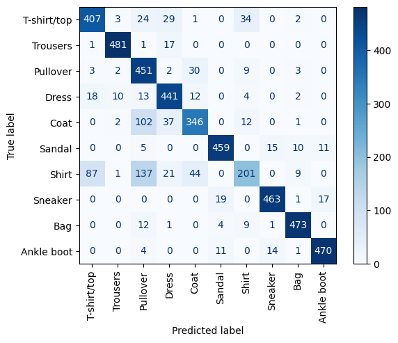

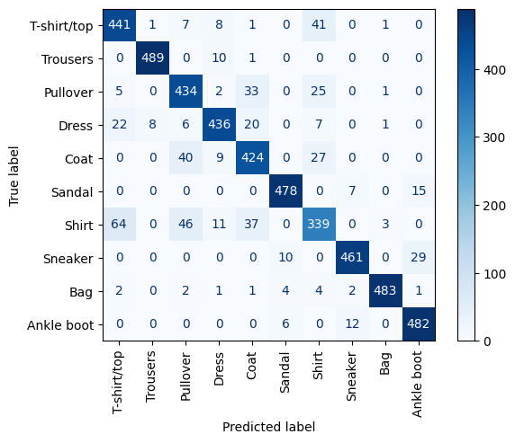

```python
plot_confusion_matrix(relu_FCNet, X_val, y_val, labels)
plot_confusion_matrix(relu_FCNet_scaled, X_val, y_val, labels)
```

Looking at the baseline, it seems to get tripped up on shirts the most often. \ When the image is of a shirt, the model often thinks its a T-shirt/Top, Pullover, Coat or Dress which, to be fair, is really not that unreasonable of a mistake to make. \ \ \ Looking at the broader scope, the confusion matrix is approx. symmetrical about the diagonal, with the whole group of \ T-shirt/Top, Pullover, Coat, Shirt and Dress often being msitaken for one of the reamining. \ Sneakers and Ankle Boots also seem to exhibit a similar example but too a much smaller degree \ \ \ The easisest cateogory to identify seems to be Trousers, and when they are misidentified they mostly seem to be mistaken as dresses \ which, if you'll recall the average pixels plot, is not too unreasonable either. \ \ Overall, the baseline seems to perform quite well and is surprisngly effective for this task. \ \ Final Metrics: 89.34% val_acc, Shirts: 339/500

## Practical Convolutional Network

With the performance of a classical neural network in mind, let's now move on to the real meat of this notebook: CNNs \ Since their architectures and motivations are completely diferrent from a classical neural network, it will be interesting to see how much it improves over our baseline. \ In addition, the A/B scaling test is performed again to see if the results are diferent for a different architecture. \ \ Starting off with a simple and basic CNN, we'll now evaluate and see how it holds up

```python
prac_cnn = Sequential()

prac_cnn.add(fashion_input)
prac_cnn.add(Conv2D(32, (5, 5), activation='relu'))
prac_cnn.add(MaxPooling2D(pool_size=(2, 2)))
prac_cnn.add(Flatten())
prac_cnn.add(Dense(128, activation='relu'))
prac_cnn.add(Dense(10, activation='softmax'))

prac_cnn.compile(
    optimizer="adam", loss="categorical_crossentropy", metrics=["accuracy"]
)
prac_cnn.summary()

# Model taken from practical worksheet
```

```
Model: "sequential_3"
_________________________________________________________________
 Layer (type)                Output Shape              Param #
=================================================================
 conv2d (Conv2D)             (None, 24, 24, 32)        832

 max_pooling2d (MaxPooling2D  (None, 12, 12, 32)       0
 )

 flatten_3 (Flatten)         (None, 4608)              0

 dense_6 (Dense)             (None, 128)               589952

 dense_7 (Dense)             (None, 10)                1290

=================================================================
Total params: 592,074
Trainable params: 592,074
Non-trainable params: 0
_________________________________________________________________
```

```python
prac_cnn_history = prac_cnn.fit(
    X_train,
    y_train_enc,
    epochs=10,
    validation_data=(X_val, y_val_enc),
)
```

```python
prac_cnn_scaled = Sequential()

prac_cnn_scaled.add(fashion_input)
prac_cnn_scaled.add(pixel_scaler)
prac_cnn_scaled.add(Conv2D(32, (5, 5), activation='relu'))
prac_cnn_scaled.add(MaxPooling2D(pool_size=(2, 2)))
prac_cnn_scaled.add(Flatten())
prac_cnn_scaled.add(Dense(128, activation='relu'))
prac_cnn_scaled.add(Dense(10, activation='softmax'))

prac_cnn_scaled.compile(
    optimizer="adam", loss="categorical_crossentropy", metrics=["accuracy"]
)
prac_cnn_scaled.summary()
```

```
Model: "sequential_4"
_________________________________________________________________
 Layer (type)                Output Shape              Param #
=================================================================
 rescaling_2 (Rescaling)     multiple                  0

 conv2d_1 (Conv2D)           (None, 24, 24, 32)        832

 max_pooling2d_1 (MaxPooling  (None, 12, 12, 32)       0
 2D)

 flatten_4 (Flatten)         (None, 4608)              0

 dense_8 (Dense)             (None, 128)               589952

 dense_9 (Dense)             (None, 10)                1290

=================================================================
Total params: 592,074
Trainable params: 592,074
Non-trainable params: 0
_________________________________________________________________
```

```python
prac_cnn_scaled_history = prac_cnn_scaled.fit(
    X_train,
    y_train_enc,
    epochs=10,
    validation_data=(X_val, y_val_enc),
)
```

### Model Evaluation

```python
plot_learning_curves(prac_cnn_history)
```

```python
plot_learning_curves(prac_cnn_scaled_history)
```

However, the curves also show signs of overfitting, with the validation curves diverging from the trainnig curves after 3 epochs. \

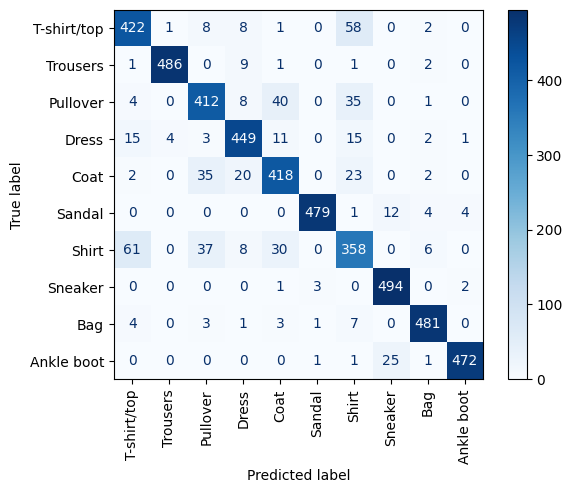

```python
plot_confusion_matrix(prac_cnn, X_val, y_val, labels)
```

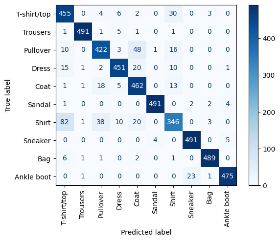

```python
plot_confusion_matrix(prac_cnn_scaled, X_val, y_val, labels)
```

Looking at the confusino matrix, the CNN seems to fall into the same pitfalls as the full-connected network, being tripped up by mainly the upperbody wear pals. However, it has managed to improved slightly over the fully-connected network, getting slightly lesser samples wrong. \ In addition, it interestingly has gottne even better at finding Trousers and gotten to the same level of confidence for Sneakers and Sandals \ \ Despite this, it came at a 500,000+ increase in the number of parameters, which reduce the novelty and elegance of the model a little in my eyes, \ but better performance is better performance, and we can only go up from here.

## Modified Practical CNN

With the performance of a simple CNN established, let's now see what a slightly more complex architecture can do.

First, inspired by VGG blocks, I increased the number of convolutional layers from 1 to 2 blocks of 2 and added max pooling layers between them. \ Doing so can hopefully help the model abstarct out more visual features from the images, ideally things like the smaller collars of Coats or wider chests of Shirts. \ I also decreased the kernel sizes from 5x5 to 3x3, since doing so will decrease the number of parameters while allowing for a deeper network, which is perfect for wanting to \ improve generalisation \ \ In additino, I inserted another dense layer at the bottom to add another layer of abstraction between the final convolutions and the output to hopefully \ draw out more complex patterns

```python
double_cnn = Sequential()

double_cnn.add(fashion_input)
double_cnn.add(pixel_scaler)
double_cnn.add(Conv2D(32, (3, 3), activation='relu'))
double_cnn.add(Conv2D(32, (3, 3), activation='relu'))
double_cnn.add(MaxPooling2D(pool_size=(2, 2)))
double_cnn.add(Conv2D(64, (3, 3), activation='relu', padding="same"))
double_cnn.add(Conv2D(64, (3, 3), activation='relu', padding="same"))
double_cnn.add(MaxPooling2D(pool_size=(2, 2)))
double_cnn.add(Flatten())
double_cnn.add(Dense(100, activation='relu'))
double_cnn.add(Dense(100, activation='relu'))
double_cnn.add(Dense(10, activation='softmax'))

double_cnn.compile(
    optimizer="adam", loss="categorical_crossentropy", metrics=["accuracy"]
)
double_cnn.summary()
```

```
Model: "sequential_2"
_________________________________________________________________
 Layer (type)                Output Shape              Param #
=================================================================
 rescaling (Rescaling)       multiple                  0

 conv2d_1 (Conv2D)           (None, 26, 26, 32)        320

 conv2d_2 (Conv2D)           (None, 24, 24, 32)        9248

 max_pooling2d_1 (MaxPooling  (None, 12, 12, 32)       0
 2D)

 conv2d_3 (Conv2D)           (None, 12, 12, 64)        18496

 conv2d_4 (Conv2D)           (None, 12, 12, 64)        36928

 max_pooling2d_2 (MaxPooling  (None, 6, 6, 64)         0
 2D)

 flatten_2 (Flatten)         (None, 2304)              0

 dense_4 (Dense)             (None, 100)               230500

 dense_5 (Dense)             (None, 100)               10100

 dense_6 (Dense)             (None, 10)                1010

=================================================================
Total params: 306,602
Trainable params: 306,602
Non-trainable params: 0
_________________________________________________________________
```

```python
double_cnn_history = double_cnn.fit(
    X_train,
    y_train_enc,
    epochs=100,
    batch_size=1000,
    validation_data=(X_val, y_val_enc),    callbacks=[
        CSVLogger("histories/double_cnn.csv"),
        ModelCheckpoint("checkpoints/double_cnn.h5", monitor="val_accuracy", save_best_only=True),
        earlyStop
    ],
)
```

### Model Evaluation

```python
double_cnn = keras.models.load_model("./checkpoints/double_cnn.h5")
double_cnn_history = pd.read_csv('./histories/double_cnn.csv')
```

```python
plot_learning_curves(double_cnn_history)
```

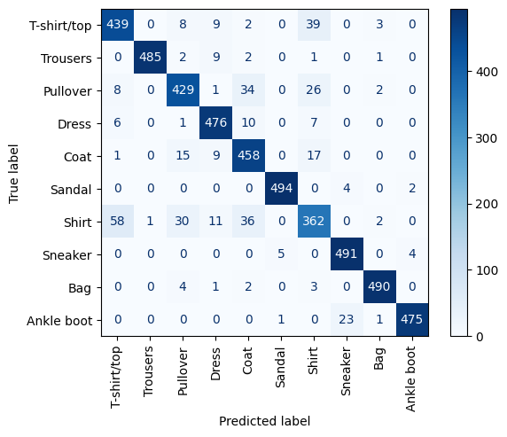

```python
plot_confusion_matrix(double_cnn, X_val, y_val, labels)
```

Still, the model has much more it can achieve, and to help it get there we have to start regularising it

## Regularisation

### Dropout Layers

The first technique I'll be using is Dropout, where some of the connections between layers are temporarily turned off at random. \ I find this regularisation technique the most fascinating (hence why I'm starting with it) as the possible justifications for why it works are all \ simple to accept intuitively (unlike most of Deep Learning and its tensor mathematics) \ and it has demonstrated to be wonderfully effective in more complex applications. \

There are a few explanations as to why Dropout works. First, dropout possibly prevent neurons from relying on each other too strongly. Since the connection between neurons can be cut at anytime, the model has to update \ each neuron in such a way that all of them will minimise the loss function in some way. This makes it so that every neuron learns to fit the data set instead \ instead of just letting a specific subset do the heavy lifting \ Another explantion is that by dropping out connections, we are essentially training different models with their own varied number of neurons. Then, at predict time, these models \ with their own learned wieghts work with each other to predict the image, basically ensembling a collection of trained neural networks. \

However, Dropout is in practice turning off parts of our model, so it still has to be applied carefully otherwise we might end up taking away all of the capabilities of our network. \ This is usually addressed by dropping out connections closer to the output as these are usually the ones that learn the quickest by virtue of being closer to the cost function and thus most likely to reap the benefits of dropout

#### Neuron Dropout

Starting with regular dropout, which sets the activations out of some neurons to zero. \ I applied dropout selectively to only the dense layers as is common practice in CNNs since removing single neurons in a convolutional layer \ isn't as dramatic due to the realtionship between multiple adjacent pixels in a filter.

```python
dropout = Sequential()

dropout.add(fashion_input)
dropout.add(pixel_scaler)
dropout.add(Conv2D(32, (3, 3), activation='relu'))
dropout.add(Conv2D(32, (3, 3), activation='relu'))
dropout.add(MaxPooling2D(pool_size=(2, 2)))
dropout.add(Conv2D(64, (3, 3), activation='relu', padding="same"))
dropout.add(Conv2D(64, (3, 3), activation='relu', padding="same"))
dropout.add(MaxPooling2D(pool_size=(2, 2)))
dropout.add(Flatten())
dropout.add(Dropout(0.5))
dropout.add(Dense(100, activation='relu'))
dropout.add(Dropout(0.5))
dropout.add(Dense(100, activation='relu'))
dropout.add(Dense(10, activation='softmax'))

dropout.compile(
    optimizer="adam", loss="categorical_crossentropy", metrics=["accuracy"]
)

dropout.summary()
```

```
Model: "sequential_3"
_________________________________________________________________
 Layer (type)                Output Shape              Param #
=================================================================
 rescaling (Rescaling)       multiple                  0

 conv2d_5 (Conv2D)           (None, 26, 26, 32)        320

 conv2d_6 (Conv2D)           (None, 24, 24, 32)        9248

 max_pooling2d_3 (MaxPooling  (None, 12, 12, 32)       0
 2D)

 conv2d_7 (Conv2D)           (None, 12, 12, 64)        18496

 conv2d_8 (Conv2D)           (None, 12, 12, 64)        36928

 max_pooling2d_4 (MaxPooling  (None, 6, 6, 64)         0
 2D)

 flatten_3 (Flatten)         (None, 2304)              0

 dropout (Dropout)           (None, 2304)              0

 dense_7 (Dense)             (None, 100)               230500

 dropout_1 (Dropout)         (None, 100)               0

 dense_8 (Dense)             (None, 100)               10100

 dense_9 (Dense)             (None, 10)                1010

=================================================================
Total params: 306,602
Trainable params: 306,602
Non-trainable params: 0
_________________________________________________________________
```

```python
dropout_history = dropout.fit(
    X_train,
    y_train_enc,
    epochs=100,
    batch_size=1000,
    validation_data=(X_val, y_val_enc),    callbacks=[
        CSVLogger("histories/dropout.csv"),
        ModelCheckpoint("checkpoints/dropout.h5", monitor="val_accuracy", save_best_only=True),
        earlyStop
    ],
)
```

##### Model Evaluation

```python
dropout = keras.models.load_model("./checkpoints/dropout.h5")

dropout_history = pd.read_csv('./histories/dropout.csv')
```

```python
plot_learning_curves(dropout_history)
```

With Dropout applied, the regularising effect is immediately apparent. The learning curves start to diverge from each other fter epoch 30 instead of at epoch 6 and the validation curves remains close to the training curve up to epoch 60, where EralyStopping cuts it off. \ The highest achieved train accuracy has gone down, signalling that the model isn't strating to memorise the train set and the validation accuracy has gone up to 93% \ Overall, the regularising effect of Dropout is amazing, with little to no additional cost in train time or params

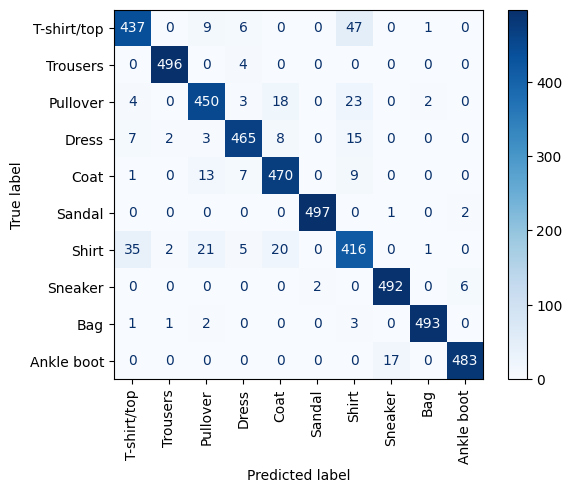

```python
plot_confusion_matrix(dropout, X_val, y_val, labels)
```

Looking at the confusion matrix, with Dropout the performance has drastically improved, with all classes getting at least 400/500 correct. \ Mistakes everywhere other than the typical few are practically non-existent now, and improving from here on out jsut involves differentiating \ between different types of upper body wear and between sneakers and ankle boots (both of which are fairly ambiguous tasks)

#### Spatial Dropout

Spatial Dropout works on the same principles as regular dropout but applied to filters instead of single neurons, making it more suited to Convoltional layers

```python
spatial_dropout = Sequential()

spatial_dropout.add(fashion_input)
spatial_dropout.add(pixel_scaler)
spatial_dropout.add(Conv2D(32, (3, 3), activation='relu'))
spatial_dropout.add(SpatialDropout2D(0.3))
spatial_dropout.add(Conv2D(32, (3, 3), activation='relu'))
spatial_dropout.add(SpatialDropout2D(0.3))

spatial_dropout.add(MaxPooling2D(pool_size=(2, 2)))
spatial_dropout.add(Conv2D(64, (3, 3), activation='relu', padding="same"))
spatial_dropout.add(SpatialDropout2D(0.3))
spatial_dropout.add(Conv2D(64, (3, 3), activation='relu', padding="same"))
spatial_dropout.add(SpatialDropout2D(0.3))

spatial_dropout.add(MaxPooling2D(pool_size=(2, 2)))
spatial_dropout.add(Flatten())
spatial_dropout.add(Dense(100, activation='relu'))
spatial_dropout.add(Dense(100, activation='relu'))
spatial_dropout.add(Dense(10, activation='softmax'))

spatial_dropout.compile(
    optimizer="adam", loss="categorical_crossentropy", metrics=["accuracy"]
)

spatial_dropout.summary()
```

```
Model: "sequential_5"
_________________________________________________________________
 Layer (type)                Output Shape              Param #
=================================================================
 rescaling (Rescaling)       multiple                  0

 conv2d_13 (Conv2D)          (None, 26, 26, 32)        320

 spatial_dropout2d (SpatialD  (None, 26, 26, 32)       0
 ropout2D)

 conv2d_14 (Conv2D)          (None, 24, 24, 32)        9248

 spatial_dropout2d_1 (Spatia  (None, 24, 24, 32)       0
 lDropout2D)

 max_pooling2d_7 (MaxPooling  (None, 12, 12, 32)       0
 2D)

 conv2d_15 (Conv2D)          (None, 12, 12, 64)        18496

 spatial_dropout2d_2 (Spatia  (None, 12, 12, 64)       0
 lDropout2D)

 conv2d_16 (Conv2D)          (None, 12, 12, 64)        36928

 spatial_dropout2d_3 (Spatia  (None, 12, 12, 64)       0
 lDropout2D)

 max_pooling2d_8 (MaxPooling  (None, 6, 6, 64)         0
 2D)

 flatten_5 (Flatten)         (None, 2304)              0

 dense_13 (Dense)            (None, 100)               230500

 dense_14 (Dense)            (None, 100)               10100

 dense_15 (Dense)            (None, 10)                1010

=================================================================
Total params: 306,602
Trainable params: 306,602
Non-trainable params: 0
_________________________________________________________________
```

```python
spatial_dropout_history = spatial_dropout.fit(
    X_train,
    y_train_enc,
    epochs=100,
    batch_size=1000,
    validation_data=(X_val, y_val_enc),
    callbacks=[
        CSVLogger("histories/spatial_dropout.csv"),
        ModelCheckpoint("checkpoints/spatial_dropout.h5", monitor="val_accuracy", save_best_only=True),
        earlyStop
    ],
)
```

##### Model Evaluation

```python
spatial_dropout = keras.models.load_model("./checkpoints/spatial_dropout.h5")

spatial_dropout_history = pd.read_csv('./histories/spatial_dropout.csv')
```

```python
plot_learning_curves(spatial_dropout_history)
```

The learning curves show taht Spatial Dropout has reduced overfitting, and the train accuracies have imrpoved similarly as with regular Dropout. \ \ overall, the effects of Spatial Dorpout seem comparable to Regular Dropout

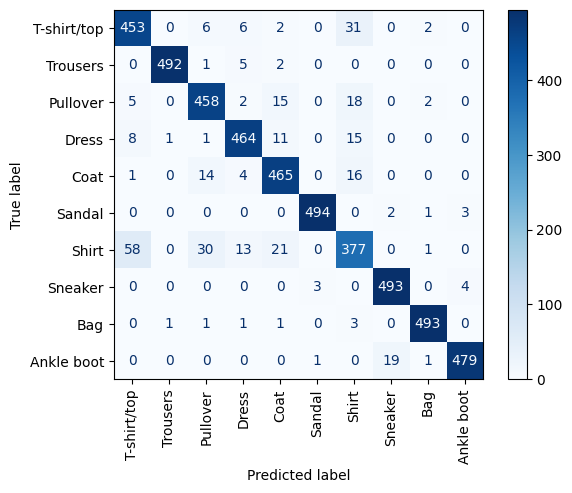

```python
plot_confusion_matrix(spatial_dropout, X_val, y_val, labels)
```

Once again, the old regulars have confused the poor model and contribute to most of its errors. \ Interestingly, the spatial dropout model didn;t performe much better in finding Shirts, instead most of its improvements went to increasing identifying T-shirts/Tops Perhaps the potential lack of sleeves in the T-shirt/Tops class was better identified with dropout applied to the whole filters \ Final Metrics: 93.2% val_acc, Shirts: 377/500 (to non-regularized)

### Weight Regularization

Another type of regularisation is weight regularisation, where we add the magnitude of the weights into the cost function, essentially telling the model \ to prefer smaller weights. This is similar to the AIC and BIC scores under maximum likelihood estimation, telling us how well the model likely estimates the true fit.

```python
weight_regularize = Sequential()

weight_regularize.add(fashion_input)
weight_regularize.add(pixel_scaler)
weight_regularize.add(Conv2D(32, (3, 3), activation='relu'))
weight_regularize.add(Conv2D(32, (3, 3), activation='relu'))
weight_regularize.add(MaxPooling2D(pool_size=(2, 2)))

weight_regularize.add(Conv2D(64, (3, 3), activation='relu', padding="same"))
weight_regularize.add(Conv2D(64, (3, 3), activation='relu', padding="same", kernel_regularizer="l1_l2"))
weight_regularize.add(MaxPooling2D(pool_size=(2, 2)))

weight_regularize.add(Flatten())
weight_regularize.add(Dense(100, activation='relu', kernel_regularizer="l1_l2"))
weight_regularize.add(Dense(100, activation='relu', kernel_regularizer="l1_l2"))
weight_regularize.add(Dense(10, activation='softmax'))

weight_regularize.compile(
    optimizer="adam", loss="categorical_crossentropy", metrics=["accuracy"]
)

weight_regularize.summary()
```

```
Model: "sequential_7"
_________________________________________________________________
 Layer (type)                Output Shape              Param #
=================================================================
 rescaling (Rescaling)       multiple                  0

 conv2d_21 (Conv2D)          (None, 26, 26, 32)        320

 conv2d_22 (Conv2D)          (None, 24, 24, 32)        9248

 max_pooling2d_11 (MaxPoolin  (None, 12, 12, 32)       0
 g2D)

 conv2d_23 (Conv2D)          (None, 12, 12, 64)        18496

 conv2d_24 (Conv2D)          (None, 12, 12, 64)        36928

 max_pooling2d_12 (MaxPoolin  (None, 6, 6, 64)         0
 g2D)

 flatten_7 (Flatten)         (None, 2304)              0

 dense_19 (Dense)            (None, 100)               230500

 dense_20 (Dense)            (None, 100)               10100

 dense_21 (Dense)            (None, 10)                1010

=================================================================
Total params: 306,602
Trainable params: 306,602
Non-trainable params: 0
_________________________________________________________________
```

```python
weight_regularize_history = weight_regularize.fit(
    X_train,
    y_train_enc,
    epochs=100,
    batch_size=1000,
    validation_data=(X_val, y_val_enc),
    callbacks=[
        CSVLogger("histories/weight_regularize.csv"),
        ModelCheckpoint("checkpoints/weight_regularize.h5", monitor="val_accuracy", save_best_only=True),
        earlyStop
    ],
)
```

##### Model Evaluation

```python
weight_regularize.save("./models/weight_regularize.h5")
```

```python
weight_regularize = keras.models.load_model("./models/weight_regularize.h5")
weight_regularize_history = pd.read_csv('./histories/weight_regularize.csv')
```

```python
plot_learning_curves(weight_regularize_history)
```

The curves show a a disapoointing result, with the model faring worse with L1 and L2 regularization applied. \ Although the learning curves are tighter, their magnitudes are nowhere near the non-regularized model's and are definitely worse than the other regularisatin method's. \ This means that large and specific activations are not the factors holding the model back and by adding weight regularization I seemed to have confused the model even further

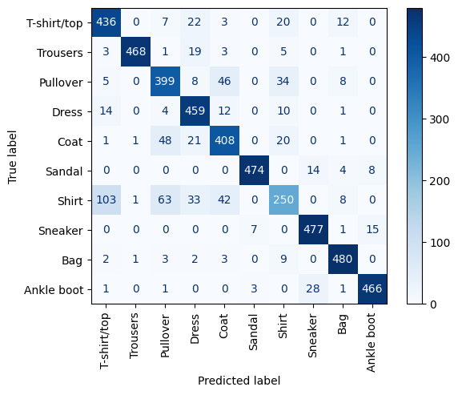

```python
plot_confusion_matrix(weight_regularize, X_val, y_val, labels)
```

As pointed out, the model performed worse then without regularization and is even more confused when confronted by the prvious troublemakers.

Final Metrics: 86.2% val_acc, Shirts: 250/500 (to non-regularized)

### All Together Now

```python
regularize = Sequential()

regularize.add(fashion_input)
regularize.add(pixel_scaler)

regularize.add(Conv2D(32, (3, 3), activation='relu'))
regularize.add(Conv2D(32, (3, 3), activation='relu'))
regularize.add(MaxPooling2D(pool_size=(2, 2)))


regularize.add(Conv2D(64, (3, 3), activation='relu', padding="same"))
regularize.add(SpatialDropout2D(0.3))
regularize.add(Conv2D(64, (3, 3), activation='relu', padding="same"))
regularize.add(SpatialDropout2D(0.3))
regularize.add(MaxPooling2D(pool_size=(2, 2)))


regularize.add(Flatten())
regularize.add(Dense(100, activation='relu'))
dropout.add(Dropout(0.5))
regularize.add(Dense(100, activation='relu'))
dropout.add(Dropout(0.5))
regularize.add(Dense(10, activation='softmax'))

regularize.compile(
    optimizer="adam", loss="categorical_crossentropy", metrics=["accuracy"]
)

regularize.summary()
```

```
Model: "sequential_19"
_________________________________________________________________
 Layer (type)                Output Shape              Param #
=================================================================
 rescaling (Rescaling)       multiple                  0

 conv2d_48 (Conv2D)          (None, 26, 26, 32)        320

 conv2d_49 (Conv2D)          (None, 24, 24, 32)        9248

 max_pooling2d_23 (MaxPoolin  (None, 12, 12, 32)       0
 g2D)

 conv2d_50 (Conv2D)          (None, 12, 12, 64)        18496

 spatial_dropout2d_13 (Spati  (None, 12, 12, 64)       0
 alDropout2D)

 conv2d_51 (Conv2D)          (None, 12, 12, 64)        36928

 spatial_dropout2d_14 (Spati  (None, 12, 12, 64)       0
 alDropout2D)

 max_pooling2d_24 (MaxPoolin  (None, 6, 6, 64)         0
 g2D)

 flatten_13 (Flatten)        (None, 2304)              0

 dense_37 (Dense)            (None, 100)               230500

 dense_38 (Dense)            (None, 100)               10100

 dense_39 (Dense)            (None, 10)                1010

=================================================================
Total params: 306,602
Trainable params: 306,602
Non-trainable params: 0
_________________________________________________________________
```

```python
regularize_history = regularize.fit(
    X_train,
    y_train_enc,
    epochs=100,
    batch_size=1000,
    validation_data=(X_val, y_val_enc),
    callbacks=[
        CSVLogger("histories/regularize.csv"),
        ModelCheckpoint("checkpoints/regularize.h5", monitor="val_accuracy", save_best_only=True),
        earlyStop
    ],
)
```

##### Model Evaluation

```python
regularize = keras.models.load_model("./checkpoints/regularize.h5")
regularize_history = pd.read_csv('./histories/regularize.csv')
```

```python
plot_learning_curves(regularize_history)
```

The curves aren't exactly tighter than the dropout methods individually, and sadly there still seems to be signs of overfitting present later after epoch 30+ \ Interestingly, the training acuracy managed to reach a higher maximum of 96% comapred to the other dropout methods. \ The training loss has also managed to hit an all-time low of 0,.09 while the others are at 0.11-0.12

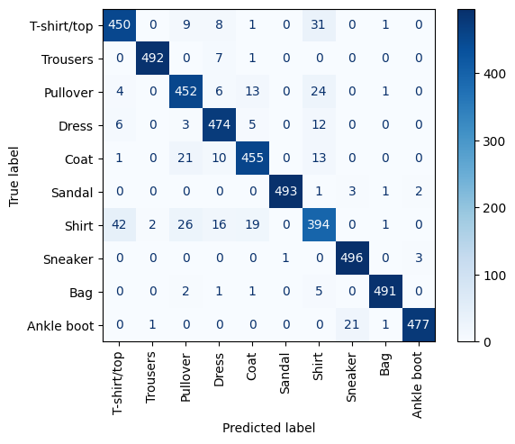

```python
plot_confusion_matrix(regularize, X_val, y_val, labels)
```

## Deeeper

With the empirical effects of dropout established, we can attempt to make our netwrok deeper to try and raise the ceiling on its performance

Changes made:

- Added am additional convolution block
- Added BatchNormalization to speed up convergence of model

```python
deeep = Sequential()

deeep.add(fashion_input)
deeep.add(pixel_scaler)
deeep.add(Conv2D(32, (3, 3), activation='relu'))
deeep.add(Conv2D(32, (3, 3), activation='relu'))
deeep.add(MaxPooling2D(pool_size=(2, 2)))

deeep.add(Conv2D(64, (3, 3), activation='relu', padding="same"))
deeep.add(BatchNormalization())
deeep.add(SpatialDropout2D(0.3))
deeep.add(Conv2D(64, (3, 3), activation='relu', padding="same"))
deeep.add(BatchNormalization())
deeep.add(SpatialDropout2D(0.3))
deeep.add(MaxPooling2D(pool_size=(2, 2)))

deeep.add(Conv2D(128, (3, 3), activation='relu', padding="same"))
deeep.add(SpatialDropout2D(0.3))
deeep.add(BatchNormalization())
deeep.add(Conv2D(128, (3, 3), activation='relu', padding="same"))
deeep.add(SpatialDropout2D(0.3))
deeep.add(BatchNormalization())
deeep.add(Conv2D(128, (3, 3), activation='relu', padding="same"))
deeep.add(SpatialDropout2D(0.3))
deeep.add(MaxPooling2D(pool_size=(2, 2)))

deeep.add(BatchNormalization())
deeep.add(Flatten())
deeep.add(Dense(100, activation='relu'))
deeep.add(Dropout(0.5))
deeep.add(BatchNormalization())
deeep.add(Dense(100, activation='relu'))
deeep.add(Dropout(0.5))
deeep.add(Dense(10, activation='softmax'))

deeep.compile(
    optimizer="adam", loss="categorical_crossentropy", metrics=["accuracy"]
)

deeep.summary()
```

```
Model: "sequential_50"
_________________________________________________________________
 Layer (type)                Output Shape              Param #
=================================================================
 rescaling (Rescaling)       multiple                  0

 conv2d_175 (Conv2D)         (None, 26, 26, 32)        320

 conv2d_176 (Conv2D)         (None, 24, 24, 32)        9248

 max_pooling2d_80 (MaxPoolin  (None, 12, 12, 32)       0
 g2D)

 conv2d_177 (Conv2D)         (None, 12, 12, 64)        18496

 batch_normalization_42 (Bat  (None, 12, 12, 64)       256
 chNormalization)

 spatial_dropout2d_98 (Spati  (None, 12, 12, 64)       0
 alDropout2D)

 conv2d_178 (Conv2D)         (None, 12, 12, 64)        36928

 batch_normalization_43 (Bat  (None, 12, 12, 64)       256
 chNormalization)

 spatial_dropout2d_99 (Spati  (None, 12, 12, 64)       0
 alDropout2D)

 max_pooling2d_81 (MaxPoolin  (None, 6, 6, 64)         0
 g2D)

 conv2d_179 (Conv2D)         (None, 6, 6, 128)         73856

 spatial_dropout2d_100 (Spat  (None, 6, 6, 128)        0
 ialDropout2D)

 batch_normalization_44 (Bat  (None, 6, 6, 128)        512
 chNormalization)

```

[output cut: 24 more lines]

```

 batch_normalization_47 (Bat  (None, 100)              400
 chNormalization)

 dense_98 (Dense)            (None, 100)               10100

 dropout_53 (Dropout)        (None, 100)               0

 dense_99 (Dense)            (None, 10)                1010

=================================================================
Total params: 562,874
Trainable params: 561,650
Non-trainable params: 1,224
_________________________________________________________________
```

```python
deeep_history = deeep.fit(
    X_train,
    y_train_enc,
    epochs=100,
    batch_size=1000,
    validation_data=(X_val, y_val_enc),    callbacks=[
        CSVLogger("histories/deeep.csv"),
        ModelCheckpoint("checkpoints/deeep.h5", monitor="val_accuracy", save_best_only=True),
        earlyStop
    ],
)
```

### Model Evaluation

```python
deeep = keras.models.load_model("./checkpoints/deeep.h5")
deeep_history = pd.read_csv('./histories/deeep.csv')
```

[output not shown]

```python
plot_learning_curves(deeep_history)
```

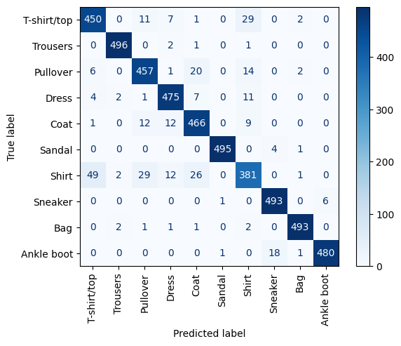

```python
plot_confusion_matrix(deeep, X_val, y_val, labels)
```

Final Metrics: 93.6% val_acc, Shirts: 381/500

### Data Augmentation

Since the models have improved but are still overftting, we can try another regularization method: Data augmentation. \ We can apply linear transformations to the data to change its pixel values while retaining its subject, essentially creating fresh data. \ \ I chose to apply horizontal flips to create more variety to handle the cases with Sneakers we found during EDA and random rotations up to pi radians \ since any more will be equivalent to some other rotation + a horizontal flip \ So with our model overfitting, perhaps these methods could help it focus less on the training set and more on generalising patterns

```python
from keras.layers import RandomFlip, RandomRotation
```

```python
data_augmentation = [
    RandomRotation(factor=(0, 0.5)),
    RandomFlip("horizontal")
]
```

```python
deeep_layers = [l for l in deeep.layers]
```

```python
augment = Sequential([fashion_input] + deeep_layers[:1] + data_augmentation + deeep_layers[1:])
augment.compile(
    optimizer="adam", loss="categorical_crossentropy", metrics=["accuracy"]
)
augment.summary()
```

```
Model: "sequential_51"
_________________________________________________________________
 Layer (type)                Output Shape              Param #
=================================================================
 rescaling (Rescaling)       (None, 28, 28, 1)         0

 random_rotation_9 (RandomRo  (None, 28, 28, 1)        0
 tation)

 random_flip_9 (RandomFlip)  (None, 28, 28, 1)         0

 conv2d_175 (Conv2D)         (None, 26, 26, 32)        320

 conv2d_176 (Conv2D)         (None, 24, 24, 32)        9248

 max_pooling2d_80 (MaxPoolin  (None, 12, 12, 32)       0
 g2D)

 conv2d_177 (Conv2D)         (None, 12, 12, 64)        18496

 batch_normalization_42 (Bat  (None, 12, 12, 64)       256
 chNormalization)

 spatial_dropout2d_98 (Spati  (None, 12, 12, 64)       0
 alDropout2D)

 conv2d_178 (Conv2D)         (None, 12, 12, 64)        36928

 batch_normalization_43 (Bat  (None, 12, 12, 64)       256
 chNormalization)

 spatial_dropout2d_99 (Spati  (None, 12, 12, 64)       0
 alDropout2D)

 max_pooling2d_81 (MaxPoolin  (None, 6, 6, 64)         0
 g2D)

 conv2d_179 (Conv2D)         (None, 6, 6, 128)         73856

 spatial_dropout2d_100 (Spat  (None, 6, 6, 128)        0
```

[output cut: 29 more lines]

```

 batch_normalization_47 (Bat  (None, 100)              400
 chNormalization)

 dense_98 (Dense)            (None, 100)               10100

 dropout_53 (Dropout)        (None, 100)               0

 dense_99 (Dense)            (None, 10)                1010

=================================================================
Total params: 562,874
Trainable params: 561,650
Non-trainable params: 1,224
_________________________________________________________________
```

```python
augment_history = augment.fit(
    X_train,
    y_train_enc,
    epochs=100,
    batch_size=1000,
    validation_data=(X_val, y_val_enc),    callbacks=[
        CSVLogger("histories/augment.csv"),
        ModelCheckpoint("checkpoints/augment.h5", monitor="val_accuracy", save_best_only=True),
        earlyStop
    ],
)
```

[output not shown]

[output cut: 49 more lines]

[output not shown]

killed augmentation because its not worth training

#### Model Evaluation

```python
augment = keras.models.load_model("./checkpoints/augment.h5")
augment_history = pd.read_csv('./histories/augment.csv')
```

```python
plot_learning_curves(augment_history)
```

The learning curves are intersting, unlike any of the prvious ones we have seen before. \ With the validation curves being consitenty above the training curves, this is a classic example of over-regularisation \ The changes introduced by the rotations and flips likely seem to have gone overboard and made the train and test conditions too different for the model to learn effectively \ In addition, the validatoin scores are worse than the one swe have seen before as well. \ \ Perhap that the current model architecture also isn't limited by access to data since the learning curves still seem to be heading up, and applying data augmentation seems to be detrimental

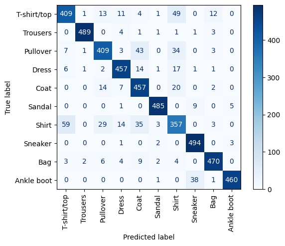

```python
plot_confusion_matrix(augment, X_val, y_val, labels)
```

Even in the case where the model is over-regularized, it seems to still achieve a reasonable score but is confused by the same classes. \ With a worse performanfce score than the others, there's not much to say about this model

Final Metrics: 89.6% val_acc, Shirts: 357/500

### Optimisers

Since the attempt at data augmentation failed, I decided to stick with the deeper model and train it until it reaches a maximum performance. \ And while we're at it, perhaps we can investigate how different optimisers control how models learn by seeing how they push the model to the maximum

#### Adam

So with our model overfitting, perhaps these methods could help it focus less on the training set and more on generalising patterns \ One of the main ways the Adam optimizer drives the model to convergence quickly is through the idea of ‘momentum’. It stores an weighted sum of past gradients to build up a sense of how much the model is moving from iteration to iteration and adds it to the calculated gradient. This is a very natural definition of momentum - accumulating the magnitude of previous downward steps.\ Using a momentum like this, perhaps the model can be pushed even further to improve its performance

\ The learning rate has also been decreased to make sure the model doesn't step too far too quickly now that we have gotten past the inital stages

```python
adam = Sequential([fashion_input] + deeep_layers)

adam.compile(
    optimizer=tf.keras.optimizers.Adam(learning_rate=0.00001), loss="categorical_crossentropy", metrics=["accuracy"]
)
adam.summary()
```

```
Model: "sequential_75"
_________________________________________________________________
 Layer (type)                Output Shape              Param #
=================================================================
 rescaling (Rescaling)       (None, 28, 28, 1)         0

 conv2d_175 (Conv2D)         (None, 26, 26, 32)        320

 conv2d_176 (Conv2D)         (None, 24, 24, 32)        9248

 max_pooling2d_80 (MaxPoolin  (None, 12, 12, 32)       0
 g2D)

 conv2d_177 (Conv2D)         (None, 12, 12, 64)        18496

 batch_normalization_42 (Bat  (None, 12, 12, 64)       256
 chNormalization)

 spatial_dropout2d_98 (Spati  (None, 12, 12, 64)       0
 alDropout2D)

 conv2d_178 (Conv2D)         (None, 12, 12, 64)        36928

 batch_normalization_43 (Bat  (None, 12, 12, 64)       256
 chNormalization)

 spatial_dropout2d_99 (Spati  (None, 12, 12, 64)       0
 alDropout2D)

 max_pooling2d_81 (MaxPoolin  (None, 6, 6, 64)         0
 g2D)

 conv2d_179 (Conv2D)         (None, 6, 6, 128)         73856

 spatial_dropout2d_100 (Spat  (None, 6, 6, 128)        0
 ialDropout2D)

 batch_normalization_44 (Bat  (None, 6, 6, 128)        512
 chNormalization)

```

[output cut: 24 more lines]

```

 batch_normalization_47 (Bat  (None, 100)              400
 chNormalization)

 dense_98 (Dense)            (None, 100)               10100

 dropout_53 (Dropout)        (None, 100)               0

 dense_99 (Dense)            (None, 10)                1010

=================================================================
Total params: 562,874
Trainable params: 561,650
Non-trainable params: 1,224
_________________________________________________________________
```

```python
adam_history = adam.fit(
    X_train,
    y_train_enc,
    epochs=30,
    batch_size=1000,
    validation_data=(X_val, y_val_enc),    callbacks=[
        CSVLogger("histories/adam.csv"),
        ModelCheckpoint("checkpoints/adam.h5", monitor="val_accuracy", save_best_only=True)
    ],
)
```

##### Model Evaluation

```python
adam = keras.models.load_model("./checkpoints/adam.h5")
adam_history = pd.read_csv('./histories/adam.csv')
```

```python
plot_learning_curves(adam_history, yranges=[[0.9, 1.0], [0, 0.5]])
```

Looking at the accuracy curves, the model seems to have hit a maximum performance of 94%, with almost no more gains The loss curve seems to have stagnated as well, in fact getting slightly larger as the epochs increase

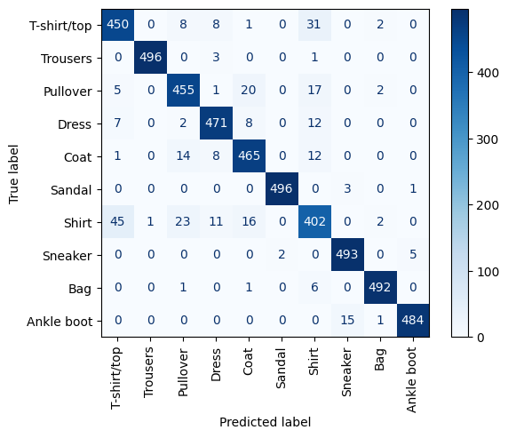

```python
plot_confusion_matrix(adam, X_val, y_val, labels)
```

The model seems to perform relatively well now, and it seems to be onyl slightly confused between the upper body wear. It seems to have the most trouble with T-shirts\Tops and T-shirts, which is in all honesty pretty understandable. \ Final Metrics: 94% val_acc, Shirts: 402/500

#### NAdam

While Adam tries to accumulate past gradients, Nadam uses a different definition of momentum to drive models to convergence. Nadam uses the gradient of the previous iteration to estimate where the model will end up after the current iteration and uses the new position to further inform the calculated gradient.\ It essentially tries to ‘look ahead’ of the model and keep it updated using future in addition to past steps. With such a different take on the definition of ‘momentum’ compared to the classic idea, it would be interesting to see how such a method might improve the performance of the model \

The learning has also been decreased for this test

```python
Nadam = Sequential([fashion_input] + deeep_layers)

Nadam.compile(
    optimizer=tf.keras.optimizers.Nadam(learning_rate=0.00001), loss="categorical_crossentropy", metrics=["accuracy"]
)
Nadam.summary()
```

```
Model: "sequential_76"
_________________________________________________________________
 Layer (type)                Output Shape              Param #
=================================================================
 rescaling (Rescaling)       (None, 28, 28, 1)         0

 conv2d_175 (Conv2D)         (None, 26, 26, 32)        320

 conv2d_176 (Conv2D)         (None, 24, 24, 32)        9248

 max_pooling2d_80 (MaxPoolin  (None, 12, 12, 32)       0
 g2D)

 conv2d_177 (Conv2D)         (None, 12, 12, 64)        18496

 batch_normalization_42 (Bat  (None, 12, 12, 64)       256
 chNormalization)

 spatial_dropout2d_98 (Spati  (None, 12, 12, 64)       0
 alDropout2D)

 conv2d_178 (Conv2D)         (None, 12, 12, 64)        36928

 batch_normalization_43 (Bat  (None, 12, 12, 64)       256
 chNormalization)

 spatial_dropout2d_99 (Spati  (None, 12, 12, 64)       0
 alDropout2D)

 max_pooling2d_81 (MaxPoolin  (None, 6, 6, 64)         0
 g2D)

 conv2d_179 (Conv2D)         (None, 6, 6, 128)         73856

 spatial_dropout2d_100 (Spat  (None, 6, 6, 128)        0
 ialDropout2D)

 batch_normalization_44 (Bat  (None, 6, 6, 128)        512
 chNormalization)

```

[output cut: 24 more lines]

```

 batch_normalization_47 (Bat  (None, 100)              400
 chNormalization)

 dense_98 (Dense)            (None, 100)               10100

 dropout_53 (Dropout)        (None, 100)               0

 dense_99 (Dense)            (None, 10)                1010

=================================================================
Total params: 562,874
Trainable params: 561,650
Non-trainable params: 1,224
_________________________________________________________________
```

```python
Nadam_history = Nadam.fit(
    X_train,
    y_train_enc,
    epochs=30,
    batch_size=1000,
    validation_data=(X_val, y_val_enc),    callbacks=[
        CSVLogger("histories/Nadam.csv"),
        ModelCheckpoint("checkpoints/Nadam.h5", monitor="val_accuracy", save_best_only=True)
    ],
)
```

##### Model Evaluation

```python
Nadam = keras.models.load_model("./checkpoints/Nadam.h5")
Nadam_history = pd.read_csv('./histories/Nadam.csv')
```

```python
plot_learning_curves(Nadam_history, yranges=[[0.9, 1.0], [0, 0.5]])
```

The Nadam curves are disappointingly similar to the learning curves that Adam produced. \ To add insult to injury, the model also performs no better than when it was trained with Adam, having almost exactly the same accuracy scores.

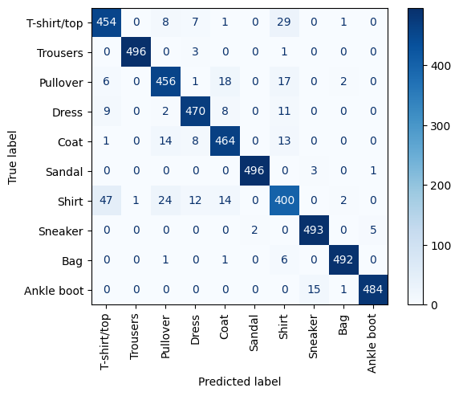

```python
plot_confusion_matrix(Nadam, X_val, y_val, labels)
```

The accuracy scores seem to be the for the most part quite similar to the Adam model as well. \ And unsurprisingly, the upper body wear are the usual offenders confusing the model.

Final Metrics: 94% val_acc, Shirts: 400/500

With the disappointing results from the tests using different optimizers, perhaps I was too optimistic in extrapolating the growth of the model. It appears that the model was already practically at its maximum, and hence would not converge too differntly with different choices.

# Model Interpretation

## Libraries

```python
from sklearn.metrics import confusion_matrix
```

```python
def plot_shirts(plots, plot_nums, cols, title=None):
    fig = make_subplots(
        rows=len(plot_nums) // cols, cols=cols, vertical_spacing=0.00000000000000001, horizontal_spacing=0.00000000000000001
    )

    for n, image in enumerate(plots[plot_nums]):
        fig.add_trace(
            px.imshow(image, binary_string=True).data[0],
            row=int(n / cols) + 1,
            col=n % cols + 1,
        )

    if title:
        fig.update_layout(title=title)

    fig.update_xaxes(showticklabels=False)
    fig.update_yaxes(showticklabels=False)
    fig.show()
```

## Interpretation

```python
relu_FCNet = keras.models.load_model('./checkpoints/relu_FCNet.h5')
regularize = keras.models.load_model("./checkpoints/regularize.h5")
deeep = keras.models.load_model("./checkpoints/deeep.h5")
best = keras.models.load_model("./checkpoints/adam.h5")
```

```python
fc_pred = np.argmax(relu_FCNet.predict(X_test), axis=1)
reg_pred = np.argmax(regularize.predict(X_test), axis=1)
deeep_pred = np.argmax(deeep.predict(X_test), axis=1)
best_pred = np.argmax(best.predict(X_test), axis=1)
```

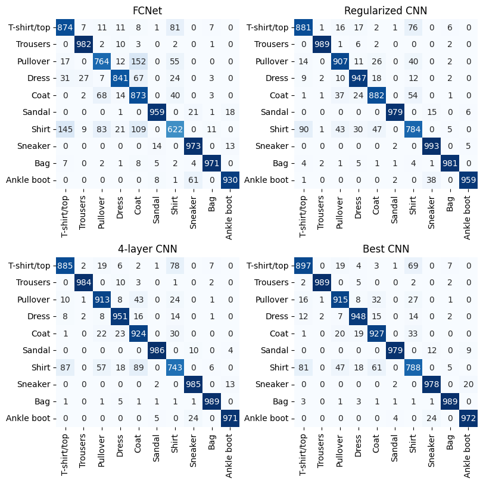

```python
fig, axs = create_subplots_axs(n_plots=4, n_cols=2, plot_w=4, plot_h=4)
axs = axs.flat

for i, pred in enumerate((fc_pred, reg_pred, deeep_pred, best_pred)):

    sns.heatmap(
    confusion_matrix(y_test, pred),
    cmap=plt.cm.Blues,
    annot=True,
    cbar=False,
    ax=axs[i],
    xticklabels=labels,
    yticklabels=labels,
    fmt="d",
)

for i, title in enumerate(('FCNet', "Regularized CNN", "4-layer CNN", "Best CNN")):
    axs[i].title.set_text(title)

plt.show()

## horizontal rows are true
## vertical columns are pred
```

```python
adam.summary()

## 562, 874 params
```

```
Model: "sequential_75"
_________________________________________________________________
 Layer (type)                Output Shape              Param #
=================================================================
 rescaling (Rescaling)       (None, 28, 28, 1)         0

 conv2d_175 (Conv2D)         (None, 26, 26, 32)        320

 conv2d_176 (Conv2D)         (None, 24, 24, 32)        9248

 max_pooling2d_80 (MaxPoolin  (None, 12, 12, 32)       0
 g2D)

 conv2d_177 (Conv2D)         (None, 12, 12, 64)        18496

 batch_normalization_42 (Bat  (None, 12, 12, 64)       256
 chNormalization)

 spatial_dropout2d_98 (Spati  (None, 12, 12, 64)       0
 alDropout2D)

 conv2d_178 (Conv2D)         (None, 12, 12, 64)        36928

 batch_normalization_43 (Bat  (None, 12, 12, 64)       256
 chNormalization)

 spatial_dropout2d_99 (Spati  (None, 12, 12, 64)       0
 alDropout2D)

 max_pooling2d_81 (MaxPoolin  (None, 6, 6, 64)         0
 g2D)

 conv2d_179 (Conv2D)         (None, 6, 6, 128)         73856

 spatial_dropout2d_100 (Spat  (None, 6, 6, 128)        0
 ialDropout2D)

 batch_normalization_44 (Bat  (None, 6, 6, 128)        512
 chNormalization)

```

[output cut: 24 more lines]

```

 batch_normalization_47 (Bat  (None, 100)              400
 chNormalization)

 dense_98 (Dense)            (None, 100)               10100

 dropout_53 (Dropout)        (None, 100)               0

 dense_99 (Dense)            (None, 10)                1010

=================================================================
Total params: 562,874
Trainable params: 561,650
Non-trainable params: 1,224
_________________________________________________________________
```

```python
(best_pred == y_test).sum()/len(y_test)
```

```
0.9382
```

```python
regularize.summary()

# 306, 602 params
```

```
Model: "sequential_13"
_________________________________________________________________
 Layer (type)                Output Shape              Param #
=================================================================
 rescaling (Rescaling)       (None, 28, 28, 1)         0

 conv2d_41 (Conv2D)          (None, 26, 26, 32)        320

 conv2d_42 (Conv2D)          (None, 24, 24, 32)        9248

 max_pooling2d_21 (MaxPoolin  (None, 12, 12, 32)       0
 g2D)

 conv2d_43 (Conv2D)          (None, 12, 12, 64)        18496

 spatial_dropout2d_11 (Spati  (None, 12, 12, 64)       0
 alDropout2D)

 conv2d_44 (Conv2D)          (None, 12, 12, 64)        36928

 spatial_dropout2d_12 (Spati  (None, 12, 12, 64)       0
 alDropout2D)

 max_pooling2d_22 (MaxPoolin  (None, 6, 6, 64)         0
 g2D)

 flatten_12 (Flatten)        (None, 2304)              0

 dense_34 (Dense)            (None, 100)               230500

 dense_35 (Dense)            (None, 100)               10100

 dense_36 (Dense)            (None, 10)                1010

=================================================================
Total params: 306,602
Trainable params: 306,602
Non-trainable params: 0
_________________________________________________________________
```

```python
(reg_pred == y_test).sum()/len(y_test)
```

```
0.9303
```

## Shirts FN and FP

```python
fc_fn = X_test[(fc_pred != y_test) & (y_test == 6)]
reg_fn = X_test[(reg_pred != y_test) & (y_test == 6)]
deeep_fn = X_test[(deeep_pred != y_test) & (y_test == 6)]
best_fn = X_test[(best_pred != y_test) & (y_test == 6)]


fc_fp = X_test[(fc_pred == 6) & (y_test != 6)]
reg_fp = X_test[(reg_pred == 6) & (y_test != 6)]
deeep_fp = X_test[(deeep_pred == 6) & (y_test != 6)]
best_fp = X_test[(best_pred == 6) & (y_test != 6)]
```

```python
plot_shirts(reg_fn, list(range(100)), cols=20, title="Regularized CNN False Negatives")
plot_shirts(deeep_fn, list(range(100)), cols=20, title="Deeep CNN False Negatives")
plot_shirts(best_fn, list(range(100)), cols=20, title="Best CNN False Negatives")
```

Overall, these wrong shirts all have fairly non-standard designs, making it understandable that the models would misclassify them. Even I'm not too confident in identidying them as shirts when compared to choices like "Tops" or "Coats"

```python
classes_geussed, counts = np.unique(best_pred[(best_pred != y_test) & (y_test == 6)], return_counts=True)

pd.Series(counts,index=[labels[guess] for guess in classes_geussed])
```

```
T-shirt/top    81
Pullover       47
Dress          18
Coat           61
Bag             5
dtype: int64
```

```python
classes_geussed, counts = np.unique(reg_pred[(reg_pred != y_test) & (y_test == 6)], return_counts=True)

pd.Series(counts,index=[labels[guess] for guess in classes_geussed])
```

```
T-shirt/top    90
Trousers        1
Pullover       43
Dress          30
Coat           47
Bag             5
dtype: int64
```

```python
plot_shirts(reg_fp, list(range(100)), cols=20, title="Regularized CNN False Positives")
plot_shirts(deeep_fp, list(range(100)), cols=20, title="Deeep CNN False Positives")
plot_shirts(best_fp, list(range(100)), cols=20, title="Best CNN False Positives")
```

Looking at the false positives, I'm not even sure if I calculated the matrix correctly. (Although there's a possiblel dress in the Best CNN 3rd column and definitely a handbag in a few of them) \ Most of these options are could all be reasonably classified as "shirts" and I wouldn't even bat an eye, I feel like my poor model can be forgiven for mixing these up. I feel it would be unreasonbale to penalise even a human for classifying these wrongly

```python
classes_geussed, counts = np.unique(y_test[(best_pred == 6) & (y_test != 6)], return_counts=True)

pd.Series(counts,index=[labels[guess] for guess in classes_geussed])
```

```
T-shirt/top    69
Trousers        2
Pullover       27
Dress          14
Coat           33
Bag             1
dtype: int64
```

```python
classes_geussed, counts = np.unique(y_test[(reg_pred == 6) & (y_test != 6)], return_counts=True)

pd.Series(counts,index=[labels[guess] for guess in classes_geussed])
```

```
T-shirt/top    76
Pullover       40
Dress          12
Coat           54
Bag             4
dtype: int64
```